# Colorado Retail Ammunition Market Analysis

Exploratory Pricing, Availability, and Lead vs. Lead-Free Comparisons

Colorado Lead Free Analysis Team

2026-10-19

## Methods & Data Processing

### Data Collection & Scope

- **Data Sources:** Pricing and catalog data were aggregated across major brick-and-mortar storefronts in Colorado and online retailers shipping directly into the state.
- **Date Range:** Data were collected between 2026-05-27 and 2026-10-19.
- **Regulation Alignment:** Full Metal Jacket (FMJ), match target ammunition, and solid non-expanding target rounds were filtered out to reflect projectiles legally permitted for big-game harvest under Colorado Parks and Wildlife (CPW) regulations (expanding/mushrooming bullets only).
- **Caliber Focus:** Analysis is restricted to a sampling of popular Colorado big-game centerfire rifle calibers, excluding rimfire, pistol cartridges, and bulk military-surplus chamberings.

### Deduplication & Standardization

- **Product-Level Identity:** Individual listings were deduplicated across retailers using Universal Product Codes (UPC) and Manufacturer Part Numbers (MPN), falling back to title matching where identifiers were unlisted.
- **Temporal Recency:** For retailers with repeat scrapes over time, only the most recent observed price per product was retained.
- **Pricing Unit:** All costs reflect factory loaded ammunition normalized to Price Per Round (USD/rd). Box counts (20-round standard hunting boxes vs. 50-round packages) were standardized by dividing total box price by box quantity prior to aggregation.

## Dataset Overview

High-Level Market Summary (USD per Round)

| Total Listings | Mean PPR | Median PPR | Min PPR | Max PPR | IQR PPR |
| --- | --- | --- | --- | --- | --- |
| 2099 | 2.45 | 2.35 | 1.03 | 7 | 0.9 |

Across all tracked calibers and retailers, the typical price per round sits at $2.35 - the median listed above. Because high-end rounds can pull the arithmetic mean upward, this report primarily relies on the **median** (the middle price on the shelf/online) to represent where everyday consumer costs likely sit.

## Price Comparison: Lead vs. Lead-Free

### Median Pricing Dumbbell Chart

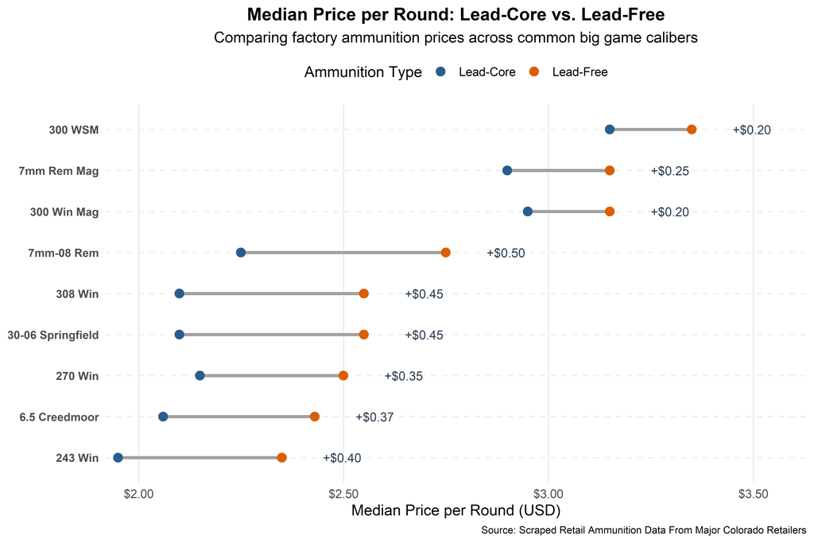

**How to read this chart:**

- Each horizontal line represents a single caliber.
- The **blue dot** marks the median price of traditional lead-core rounds.
- The **orange dot** marks the median price of lead-free (copper/monolithic) rounds.
- The grey line between the two dots illustrates the price gap, with the dollar figure at the end indicating the median price difference per round.

**Takeaway:** Lead-free ammunition carries a consistent price surcharge across standard hunting calibers - generally between **+$0.35 and +$0.50 per round** (or roughly $7.00 to $10.00 more per 20-round box). In magnum cartridges (7mm Rem Mag, 300 Win Mag, 300 WSM), premium lead-core hunting loads approach price parity with lead-free offerings, sitting at a higher initial price per round in general.

### Price Table

Median Ammunition Pricing Comparison by Caliber

| Caliber | Lead-Core ($/rd) | Lead-Free ($/rd) | Lead-Free Premium |
| --- | --- | --- | --- |
| 300 WSM | $3.15 | $3.35 | +$0.20 |
| 300 Win Mag | $2.95 | $3.15 | +$0.20 |
| 7mm Rem Mag | $2.90 | $3.15 | +$0.25 |
| 7mm-08 Rem | $2.25 | $2.75 | +$0.50 |
| 30-06 Springfield | $2.10 | $2.55 | +$0.45 |
| 308 Win | $2.10 | $2.55 | +$0.45 |
| 270 Win | $2.15 | $2.50 | +$0.35 |
| 6.5 Creedmoor | $2.06 | $2.43 | +$0.37 |
| 243 Win | $1.95 | $2.35 | +$0.40 |

The table highlights that entry costs depend heavily on the caliber itself. Historically popular cartridges like .243 Win, .308 Win, .270 and .30-06 Springfield - as well as more recent offerings including 6.5 Creedmoor - remain the most affordable overall, with the median price of lead-free loads around $2.50 per round.

## Market Availability & Distinct Offerings

### Overall Distinct Products Available

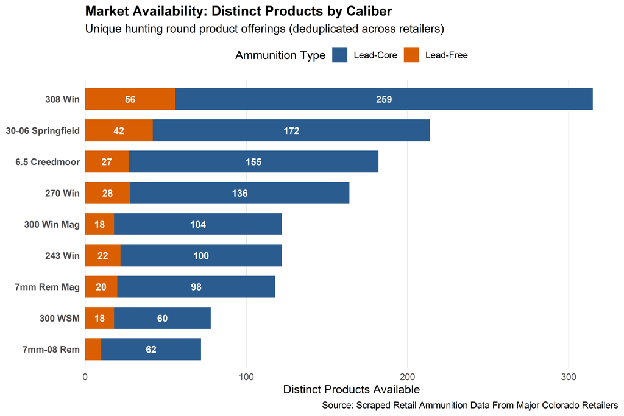

**How to read this chart:**

- **Bar Length:** The total length shows the approximate number of distinct factory choices a consumer has for that caliber.
  - *Note on data:* While offerings have been deduplicated using universal product codes (UPC) and manufacturer part numbers (MPN), minor overlap may persist due to variations in how individual retailers catalog products.
- **Color Split:** Each bar is divided into **Lead-Core (blue)** and **Lead-Free (orange)** segments, illustrating the relative product diversity between the two bullet types.

## Retailer-Level Availability

This section evaluates availability across individual storefronts - showing whether a hunter walking into a specific store or ordering from a specific retailer can reasonably expect to find lead-free choices.

Ammunition Pricing and Availability by Caliber and Retailer

| Retailer | Total Options | Lead-Core (USD/rd) Count | Lead-Core (USD/rd) Min | Lead-Core (USD/rd) Median | Lead-Core (USD/rd) Max | Lead-Free (USD/rd) Count | Lead-Free (USD/rd) Min | Lead-Free (USD/rd) Median | Lead-Free (USD/rd) Max |
| --- | --- | --- | --- | --- | --- | --- | --- | --- | --- |
| **243 Win** |  |  |  |  |  |  |  |  |  |
| Cabelas/Basspro | 35 | 29 | $1.30 | $1.90 | $3.25 | 6 | $2.00 | $2.47 | $2.65 |
| Midwayusa | 69 | 54 | $1.03 | $2.06 | $3.35 | 15 | $1.77 | $2.37 | $3.45 |
| Murdochs | 6 | 6 | $1.40 | $1.62 | $2.20 | 0 | — | — | — |
| Scheels | 57 | 48 | $1.30 | $1.92 | $3.35 | 9 | $1.85 | $2.25 | $2.85 |
| Sportsmans | 44 | 35 | $1.25 | $2.00 | $3.10 | 9 | $2.25 | $2.45 | $2.75 |
| **270 Win** |  |  |  |  |  |  |  |  |  |
| Cabelas/Basspro | 45 | 40 | $1.50 | $2.05 | $4.50 | 5 | $2.20 | $2.35 | $2.70 |
| Midwayusa | 91 | 70 | $1.23 | $2.25 | $5.50 | 21 | $1.87 | $2.65 | $3.75 |
| Murdochs | 15 | 14 | $1.60 | $2.17 | $3.75 | 1 | $2.50 | $2.50 | $2.50 |
| Scheels | 31 | 25 | $1.30 | $2.05 | $3.00 | 6 | $2.15 | $2.32 | $2.50 |
| Sportsmans | 60 | 48 | $1.50 | $2.25 | $3.50 | 12 | $2.25 | $2.60 | $3.00 |
| **30-06 Springfield** |  |  |  |  |  |  |  |  |  |
| Cabelas/Basspro | 65 | 56 | $1.40 | $2.00 | $3.45 | 9 | $2.05 | $2.70 | $3.10 |
| Midwayusa | 124 | 93 | $1.22 | $2.15 | $4.10 | 31 | $1.40 | $2.52 | $4.10 |
| Murdochs | 11 | 11 | $1.60 | $1.65 | $2.90 | 0 | — | — | — |
| Scheels | 42 | 33 | $1.40 | $2.10 | $3.35 | 9 | $2.30 | $2.45 | $2.85 |
| Sportsmans | 74 | 57 | $1.65 | $2.15 | $3.50 | 17 | $2.25 | $2.65 | $3.45 |
| **300 WSM** |  |  |  |  |  |  |  |  |  |
| Cabelas/Basspro | 19 | 15 | $2.20 | $3.25 | $5.00 | 4 | $3.40 | $3.55 | $3.75 |
| Midwayusa | 34 | 25 | $2.17 | $3.05 | $4.85 | 9 | $2.59 | $3.19 | $4.30 |
| Murdochs | 1 | 1 | $2.10 | $2.10 | $2.10 | 0 | — | — | — |
| Scheels | 26 | 21 | $1.85 | $3.15 | $4.75 | 5 | $3.00 | $3.35 | $3.65 |
| Sportsmans | 37 | 28 | $2.00 | $3.17 | $4.75 | 9 | $2.85 | $3.35 | $4.00 |
| **300 Win Mag** |  |  |  |  |  |  |  |  |  |
| Cabelas/Basspro | 49 | 43 | $1.85 | $2.75 | $4.50 | 6 | $2.75 | $3.12 | $3.50 |
| Midwayusa | 51 | 41 | $2.12 | $2.88 | $7.00 | 10 | $2.77 | $2.97 | $3.50 |
| Murdochs | 9 | 9 | $2.05 | $2.40 | $4.75 | 0 | — | — | — |
| Scheels | 36 | 26 | $1.85 | $2.97 | $4.75 | 10 | $2.80 | $3.15 | $3.60 |
| Sportsmans | 53 | 42 | $1.95 | $3.00 | $5.00 | 11 | $2.90 | $3.30 | $3.50 |
| **308 Win** |  |  |  |  |  |  |  |  |  |
| Cabelas/Basspro | 78 | 71 | $1.25 | $2.05 | $3.50 | 7 | $2.35 | $2.60 | $3.15 |
| Midwayusa | 186 | 147 | $1.20 | $2.09 | $4.10 | 39 | $1.26 | $2.52 | $4.40 |
| Murdochs | 11 | 11 | $1.60 | $1.70 | $3.40 | 0 | — | — | — |
| Scheels | 51 | 43 | $1.35 | $2.10 | $3.40 | 8 | $2.05 | $2.37 | $2.95 |
| Sportsmans | 103 | 80 | $1.25 | $2.10 | $3.50 | 23 | $1.75 | $2.65 | $3.85 |
| **6.5 Creedmoor** |  |  |  |  |  |  |  |  |  |
| Cabelas/Basspro | 44 | 42 | $1.25 | $2.25 | $3.25 | 2 | $2.60 | $2.72 | $2.85 |
| Midwayusa | 111 | 88 | $1.10 | $2.15 | $3.95 | 23 | $1.47 | $2.43 | $4.25 |
| Murdochs | 6 | 5 | $2.10 | $2.20 | $3.20 | 1 | $2.40 | $2.40 | $2.40 |
| Scheels | 43 | 38 | $1.30 | $1.95 | $2.85 | 5 | $2.05 | $2.40 | $2.95 |
| Sportsmans | 69 | 57 | $1.12 | $2.02 | $3.60 | 12 | $1.93 | $2.43 | $2.47 |
| **7mm Rem Mag** |  |  |  |  |  |  |  |  |  |
| Cabelas/Basspro | 4 | 4 | $2.75 | $3.07 | $3.15 | 0 | — | — | — |
| Midwayusa | 95 | 77 | $1.50 | $3.12 | $7.00 | 18 | $2.67 | $3.32 | $5.10 |
| Murdochs | 13 | 12 | $2.05 | $2.70 | $4.75 | 1 | $3.05 | $3.05 | $3.05 |
| Scheels | 26 | 23 | $1.75 | $2.65 | $4.65 | 3 | $2.75 | $2.90 | $3.30 |
| Sportsmans | 51 | 42 | $1.70 | $2.91 | $4.75 | 9 | $1.99 | $3.25 | $3.50 |
| **7mm-08 Rem** |  |  |  |  |  |  |  |  |  |
| Cabelas/Basspro | 14 | 13 | $1.50 | $2.20 | $2.65 | 1 | $2.95 | $2.95 | $2.95 |
| Midwayusa | 42 | 33 | $1.24 | $2.22 | $3.80 | 9 | $2.02 | $2.56 | $4.10 |
| Murdochs | 9 | 9 | $1.60 | $2.20 | $2.85 | 0 | — | — | — |
| Scheels | 21 | 19 | $1.30 | $2.10 | $2.90 | 2 | $2.25 | $2.50 | $2.75 |
| Sportsmans | 38 | 31 | $1.75 | $2.30 | $3.25 | 7 | $2.25 | $2.75 | $2.99 |

## Interactive Product Table

| Retailer | Caliber | Category | Product Name | Price | Quantity | Price / Round |
| --- | --- | --- | --- | --- | --- | --- |
| Cabelas/Basspro | 308 Win | Lead-Core | Ammo Inc Hunt SP .308 Win 165 Grain Centerfire Ammo | 34.99 | 20 | 1.7495 |
| Cabelas/Basspro | 308 Win | Lead-Core | Atomic Ammunition .308 Winchester 168 Grain Custom Competition Centerfire Rifle Ammo | 169.99 | 100 | 1.6999 |
| Cabelas/Basspro | 243 Win | Lead-Free | Barnes VOR-TX .243 Winchester 80 Grain Centerfire Rifle Ammo | 52.99 | 20 | 2.6495 |
| Cabelas/Basspro | 30-06 Springfield | Lead-Free | Barnes VOR-TX .30-06 Springfield 150 Grain TTSX Centerfire Rifle Ammo | 58.99 | 20 | 2.9495 |
| Cabelas/Basspro | 30-06 Springfield | Lead-Free | Barnes VOR-TX .30-06 Springfield 180 Grain TTSX Centerfire Rifle Ammo | 58.99 | 20 | 2.9495 |
| Cabelas/Basspro | 300 WSM | Lead-Free | Barnes VOR-TX .300 WSM Win Short Mag 165 Grain TTSX Centerfire Rifle Ammo | 74.99000000000001 | 20 | 3.7495 |
| Cabelas/Basspro | 300 Win Mag | Lead-Free | Barnes VOR-TX .300 Winchester Magnum 180 Grain TTSX Centerfire Rifle Ammo | 69.99000000000001 | 20 | 3.4995 |
| Cabelas/Basspro | 308 Win | Lead-Free | Barnes VOR-TX .308 Winchester 168 Grain Rifle Ammo | 62.99 | 20 | 3.1495 |
| Cabelas/Basspro | 6.5 Creedmoor | Lead-Core | Berger 6.5mm Creedmoor 130 Grain AR Hybrid OTM Tactical Centerfire Rifle Ammo | 49.99 | 20 | 2.4995 |
| Cabelas/Basspro | 6.5 Creedmoor | Lead-Core | Berger Elite Hunter 6.5 Creedmoor 140 Grain Centerfire Rifle Ammo | 49.99 | 20 | 2.4995 |

[output cut: 2089 more lines]

### Availability: Lead vs. Lead-Free by Retailer

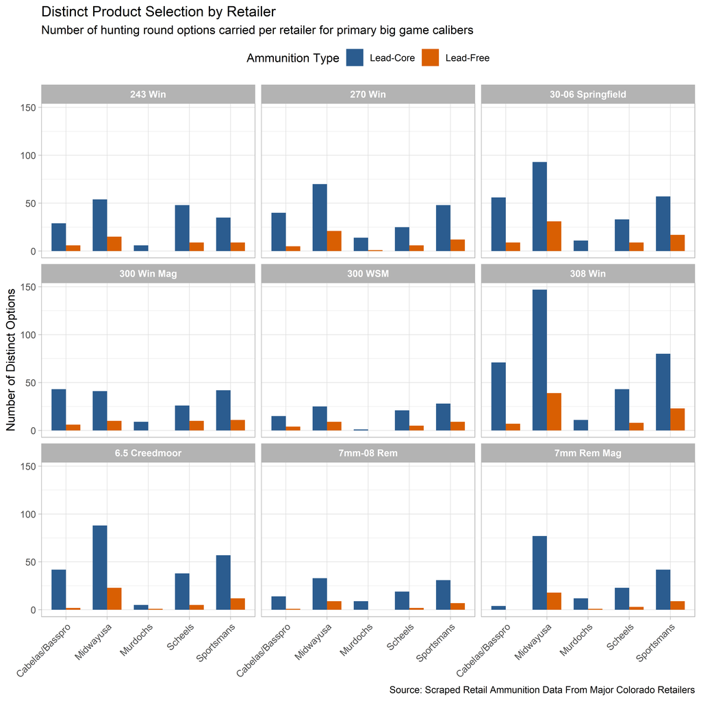

**How to read this chart:**

- Each panel represents one caliber.
- The x-axis lists the individual retailers surveyed.
- The height of the bars shows how many distinct boxes of ammunition that retailer has on offer for that caliber, directly comparing **traditional lead (blue)** against **lead-free (orange)**.

## Price Distributions: Where Do Retail Prices Cluster?

Summary averages don’t show whether options exist at budget price tiers or whether all lead-free offerings sit exclusively in the premium price bracket. The charts below display the pricing spread across distinct market offerings, using unique products with price averaged across retailers.

### Price Spread & Range (Box-and-Whisker)

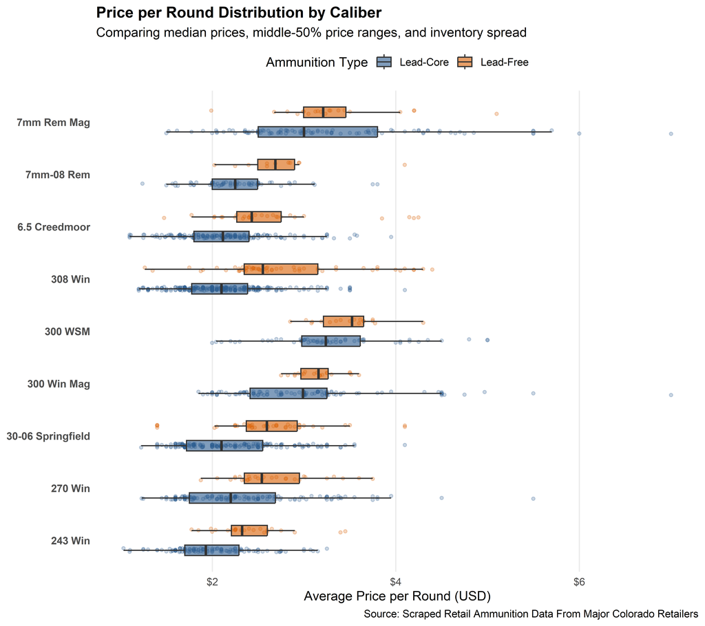

**How to read this chart:**

- **The shaded box:** Covers the middle 50% of shelf prices (the interquartile range). A shorter box means prices are clustered tightly; a taller box indicates a wide spread from budget to premium.
- **The solid line inside the box:** The median price point.
- **The “whiskers” (lines extending outward):** Show the typical upper and lower price limits for that ammunition type.
- **The faint dots:** Represent individual factory products, showing market depth and catalog variety.

### Price Histograms

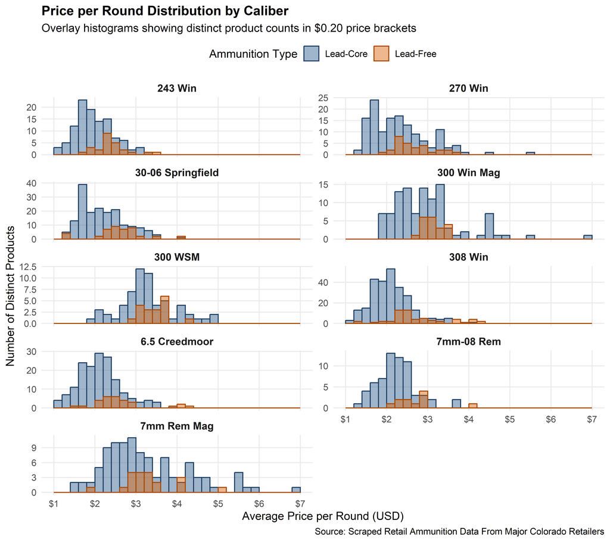

**How to read this chart:**

- Each bar stacks counts of distinct products into **$0.20 price brackets** (e.g., $2.00–$2.20, $2.20–$2.40).
- The **vertical height** shows how many unique ammunition choices - with price averaged across retailers - fall into that specific price window.
- **Overlapping colors (orange/brown tones):** Show price tiers where both lead-core and lead-free options share price brackets.

**Takeaway:** Lead-core options dominate product counts at lower price tiers (between $1.60 and $2.20), creating a tall blue wall of budget-friendly choices. Lead-free bars (orange) sit noticeably further to the right and remain comparatively low in height, showing both an elevated starting price and fewer total options to choose from.

### Count-Scaled Smooth Price Curves

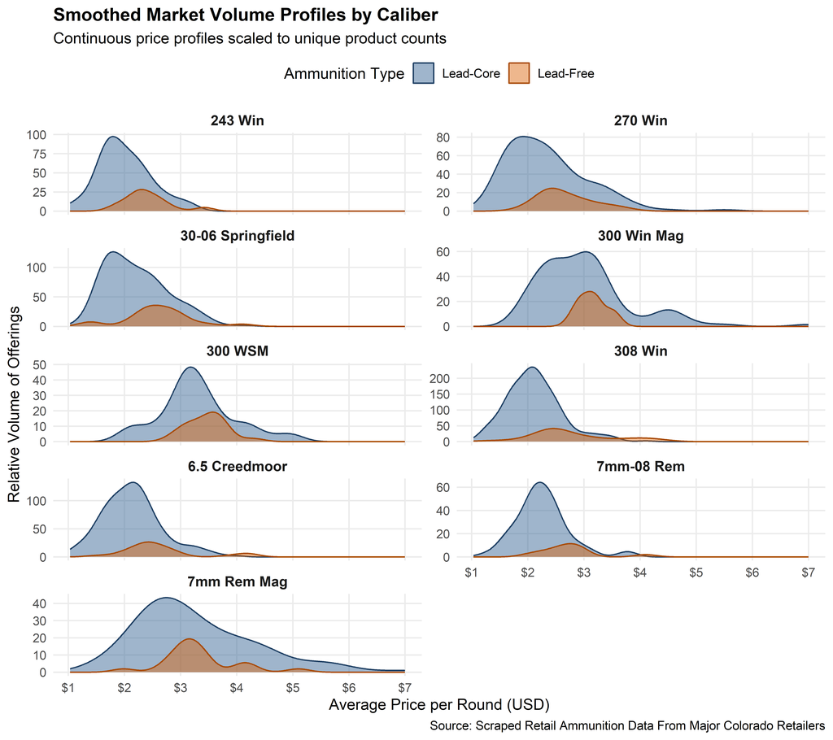

**How to read this chart:**

- Unlike standard density curves, these smoothed graphc are scaled to **actual product counts** rather than normalized percentages.
- **Peak Height:** Marks where options are most concentrated along the price spectrum. Rather than grouping prices into rigid 20-cent blocks (like a histogram), the curve reflects a continuous, rolling concentration across the data, with the tallest crest showing the price neighborhood where choices are most abundant.
- **Total Area Under the Curve:** Directly represents total market availability—a taller, wider blue curve demonstrates how much more variety exists for lead-core rounds compared to the lower orange lead-free curve.
- **Rightward Offset:** Highlights the price gap between the most common lead price point (blue peak) and the most common lead-free price point (orange peak).

**Takeaway:** This profile shows the dual challenge currently facing consumers: lead-free ammunition is both shifted toward a higher baseline price and represented by a much smaller total volume of options across nearly all calibers.